# Vector Error Correction Models (VECM)

## Introdução

Neste notebook vamos apresentar algumas das funcionalidades do módulo *vecm* que auxiliam na análise de um modelo de correção de erro vetorial *(VECM)*

$\Delta y_t = \alpha \beta^T y_{t-1} + \Gamma_1 \Delta y_{t-1} + \dots + \Gamma_{p-1} \Delta y_{t-p+1} + U_t$

Onde $ \alpha , \beta \in \mathbb{R}^{K \times r} e \Gamma_i \in \mathbb{R}^{K \times K} para i=1,...,p-1$ são os parametros e $u_t$ é $K$-dimensão ruído branco. Ambos $\alpha$ e $\beta$ tem posto $r$ o chamado posto de cointegração.

### Bibliotecas utilizadas no código

```python
%matplotlib inline
#libraries
import numpy as np
import pandas as pd
import matplotlib.pyplot as plt
from matplotlib.pyplot import tight_layout

from statsmodels.tsa.vector_ar.vecm import *
import statsmodels.datasets.interest_inflation.data as d

from sklearn import preprocessing
from sklearn.model_selection import train_test_split, TimeSeriesSplit, GridSearchCV
from sklearn.metrics import mean_absolute_percentage_error, mean_absolute_error, r2_score, mean_squared_error

import statsmodels.api as sm
from statsmodels.tsa.api import VAR
from statsmodels.tsa.stattools import adfuller

import warnings
warnings.filterwarnings('ignore')

from IPython.display import display, Markdown

pd.set_option('display.max_rows', 999)
pd.set_option('display.max_columns', 999)
pd.set_option('display.width', 800)
pd.set_option('display.max_colwidth', None)

pd.options.display.float_format = '{:.6f}'.format

plt.style.use('bmh')
plt.rcParams['font.family'] = 'Times New Roman'
plt.rcParams['font.size'] = '17'
```

### Funções Auxiliares

```python
#Funções auxiliares

def sum_billion(x):
    return round(((x.sum())/1000000000.0),2)

def sum_million(x):
    return round(((x.sum())/1000000.0),2)

def sum_thousand(x):
    return round(((x.sum())/1000.0),2)

def media_agregada(x):

    return round(((x.sum())/12.0),0)

def ignore_nans(a,b):
    index = ~a.isnull() & ~b.isnull()
    return a[index], b[index]

def timeseries_evaluation_metrics_func(y_true, y_pred):

    def smape(y_true,y_pred):
        num = np.abs(np.subtract(y_true,y_pred))
        den = (np.abs(y_true) + np.abs(y_pred)) / 2
        ratio = num/den
        return ratio.mean()

    print(f'Mean_Squared_Error_(MSE) is : {mean_squared_error(y_true,y_pred)}')
    print(f'Root_Mean_Squared_Error_(RMSE) is : {mean_squared_error(y_true,y_pred, squared=False)}')
    print(f'Mean_Absolute_Error_(MAE) is : {mean_absolute_error(y_true,y_pred)}')
    print(f'Mean_Absolute_Percentage_Error (MAPE) is : {mean_absolute_percentage_error(y_true,y_pred)}')
    print(f'Symmetrical_Mean_Absolute_Percentage_Error (MAPE) is : {smape(y_true,y_pred)}')
    print(f'Coefficient of determination R^2 is : {r2_score(y_true,y_pred)}', end = '\n\n')

    return

def timeseries_evaluation_metrics_func2(y_true, y_pred):

    def smape(y_true,y_pred):
        num = np.abs(np.subtract(y_true,y_pred))
        den = (np.abs(y_true) + np.abs(y_pred)) / 2
        ratio = num/den
        return ratio.mean()

    print(f'Mean_Squared_Error_(MSE) is : {mean_squared_error(y_true,y_pred)}')
    print(f'Root_Mean_Squared_Error_(RMSE) is : {mean_squared_error(y_true,y_pred, squared=False)}')
    print(f'Mean_Absolute_Error_(MAE) is : {mean_absolute_error(y_true,y_pred)}')
    print(f'Mean_Absolute_Percentage_Error (MAPE) is : {mean_absolute_percentage_error(y_true,y_pred)}')
    print(f'Symmetrical_Mean_Absolute_Percentage_Error (sMAPE) is : {smape(y_true,y_pred)}')
    print(f'Coefficient of determination R^2 is : {r2_score(y_true,y_pred)}', end = '\n\n')

    df_evaluation_metrics = pd.DataFrame({'metrics': ['MSE','RMSE','MAE','MAPE','sMAPE','R^2'],
                                          'scores':[mean_squared_error(y_true,y_pred),
                                                    mean_squared_error(y_true,y_pred, squared=False),
                                                    mean_absolute_error(y_true,y_pred),
                                                    mean_absolute_percentage_error(y_true,y_pred),
                                                    smape(y_true,y_pred),
                                                    r2_score(y_true,y_pred)]})

    return df_evaluation_metrics


def Augmented_Dickey_Fuller_Test_func(series, column_name):

    print(f'Results of Dickey-Fuller Test for column {column_name}')
    dftest = adfuller(series, autolag='AIC')
    dfoutput = pd.Series(dftest[0:4], index=[   'Test Statistic',
                                                'p-value',
                                                'No Lags Used',
                                                'Number of Observartions Used'])

    for key, value in dftest[4].items():
        dfoutput['Critical Value (%s)' %key] = value

    print(dfoutput)

    if dftest[1] <= 0.05:
        print('Conclusion:====>')
        print('Reject the null hypothesis')
        print('Data is stationary')
    else:
        print('Conclusion:====>')
        print('Fail to reject the null hypothesis')
        print('Data is non-stationary')
```

### Carregamento e leituras dos dados

```python
#df = d.load_pandas().data
#df.hea

#Definição do segmento a ser estudado neste código
grupo = 'Adesão - Grande - Cooperativa Médica'

grupo_csv = "ade_g_coopmed.csv"

#Criação do caminho para a leitura dos arquivo
path = r'D:\TCC\tcc-main\codigos\preparacao_dados\analise_agrupadas\adesao\porte_grande\adesao_grande_cooperativa_medica' + '\\' + grupo_csv

#Carregamento na memória da base com dados compilados
ans = pd.read_csv(path, sep=';', decimal= ',', encoding='mbcs')

#informações gerais sobre o dataframe
display(ans.info())

display(ans.head(3))

display(ans.tail(3))
```

```
<class 'pandas.core.frame.DataFrame'>
RangeIndex: 616 entries, 0 to 615
Data columns (total 9 columns):
 #   Column       Non-Null Count  Dtype
---  ------       --------------  -----
 0   ano          616 non-null    int64
 1   cd_ops       616 non-null    int64
 2   trimestre    616 non-null    object
 3   receita      616 non-null    float64
 4   despesa      616 non-null    float64
 5   benef        616 non-null    int64
 6   modalidade   616 non-null    object
 7   port_ops     616 non-null    object
 8   contratacao  616 non-null    object
dtypes: float64(2), int64(3), object(4)
memory usage: 43.4+ KB
```

```
None
```

|  | ano | cd_ops | trimestre | receita | despesa | benef | modalidade | port_ops | contratacao |
| --- | --- | --- | --- | --- | --- | --- | --- | --- | --- |
| 0 | 2018 | 303976 | 2018Q1 | 29314392.257021 | 23298026.977992 | 27209 | Cooperativa Médica | Grande | Adesao |
| 1 | 2018 | 342084 | 2018Q1 | 100884002.779270 | 71227129.013183 | 50901 | Cooperativa Médica | Grande | Adesao |
| 2 | 2018 | 348295 | 2018Q2 | 4388045.611102 | 4255788.456775 | 6692 | Cooperativa Médica | Grande | Adesao |

|  | ano | cd_ops | trimestre | receita | despesa | benef | modalidade | port_ops | contratacao |
| --- | --- | --- | --- | --- | --- | --- | --- | --- | --- |
| 613 | 2021 | 335592 | 2021Q3 | 41343270.680000 | 32885588.800000 | 42301 | Cooperativa Médica | Grande | Adesao |
| 614 | 2021 | 334561 | 2021Q3 | 11510500.130000 | 10698906.490000 | 6023 | Cooperativa Médica | Grande | Adesao |
| 615 | 2021 | 393321 | 2021Q4 | 586169428.782351 | 474987819.997087 | 282565 | Cooperativa Médica | Grande | Adesao |

### Agrupamento dos dados de receita, despesa e beneficiários por trimestre

Este dataframe será utilizado nas predições abordadas neste código

```python
ans_agrup = ans.groupby(['ano','trimestre'], as_index=False).agg({  'receita':lambda x: sum_billion(x),
                                                                    'despesa':lambda x: sum_billion(x),
                                                                    'benef': 'sum',
                                                                    'cd_ops':lambda x: x.nunique()})

ans_agrup['pct_despesa'] = ans_agrup.apply(lambda x: (x['despesa']/x['receita'])*100 , axis = 1).round(2)

ans_agrup.columns = ['ano','trimestre','receita','despesa','benef','n_ops','pct_despesa']

ans_agrup = ans_agrup[['trimestre','receita','despesa','benef','n_ops','pct_despesa']]

ans_agrup = ans_agrup[(ans_agrup.trimestre > '2017Q4') & (ans_agrup.trimestre < '2022Q1')]

ans_agrup[['n_ops','benef']] = ans_agrup[['n_ops','benef']].astype('int')

ans_agrup['trimestre'] = pd.PeriodIndex(ans_agrup['trimestre'], freq="Q")

ans_agrup['benefm'] = ans_agrup['benef'] / 3.0

#Tratamento de outliers
ans_agrup['despesa'].iloc[3] = (ans_agrup['despesa'].iloc[2] + ans_agrup['despesa'].iloc[4]) / 2.0

ans_agrup.info()

ans_agrup
```

```
<class 'pandas.core.frame.DataFrame'>
Int64Index: 16 entries, 0 to 15
Data columns (total 7 columns):
 #   Column       Non-Null Count  Dtype
---  ------       --------------  -----
 0   trimestre    16 non-null     period[Q-DEC]
 1   receita      16 non-null     float64
 2   despesa      16 non-null     float64
 3   benef        16 non-null     int32
 4   n_ops        16 non-null     int32
 5   pct_despesa  16 non-null     float64
 6   benefm       16 non-null     float64
dtypes: float64(4), int32(2), period[Q-DEC](1)
memory usage: 896.0 bytes
```

|  | trimestre | receita | despesa | benef | n_ops | pct_despesa | benefm |
| --- | --- | --- | --- | --- | --- | --- | --- |
| 0 | 2018Q1 | 2.150000 | 1.580000 | 1655264 | 38 | 73.490000 | 551754.666667 |
| 1 | 2018Q2 | 2.160000 | 1.640000 | 1667369 | 38 | 75.930000 | 555789.666667 |
| 2 | 2018Q3 | 2.290000 | 1.850000 | 1678692 | 38 | 80.790000 | 559564.000000 |
| 3 | 2018Q4 | 2.380000 | 1.860000 | 1693379 | 38 | 52.520000 | 564459.666667 |
| 4 | 2019Q1 | 2.370000 | 1.870000 | 1700602 | 38 | 78.900000 | 566867.333333 |
| 5 | 2019Q2 | 2.460000 | 1.980000 | 1730500 | 38 | 80.490000 | 576833.333333 |
| 6 | 2019Q3 | 2.550000 | 1.950000 | 1733529 | 38 | 76.470000 | 577843.000000 |
| 7 | 2019Q4 | 2.650000 | 2.080000 | 1757501 | 38 | 78.490000 | 585833.666667 |
| 8 | 2020Q1 | 2.750000 | 2.100000 | 1876410 | 39 | 76.360000 | 625470.000000 |
| 9 | 2020Q2 | 2.790000 | 1.750000 | 1892513 | 39 | 62.720000 | 630837.666667 |
| 10 | 2020Q3 | 2.830000 | 2.150000 | 1917215 | 39 | 75.970000 | 639071.666667 |
| 11 | 2020Q4 | 2.980000 | 2.460000 | 1944236 | 39 | 82.550000 | 648078.666667 |
| 12 | 2021Q1 | 3.100000 | 2.410000 | 1937524 | 39 | 77.740000 | 645841.333333 |
| 13 | 2021Q2 | 3.140000 | 2.650000 | 1949013 | 39 | 84.390000 | 649671.000000 |
| 14 | 2021Q3 | 3.200000 | 2.670000 | 1957853 | 39 | 83.440000 | 652617.666667 |
| 15 | 2021Q4 | 3.270000 | 2.700000 | 1974489 | 39 | 82.570000 | 658163.000000 |

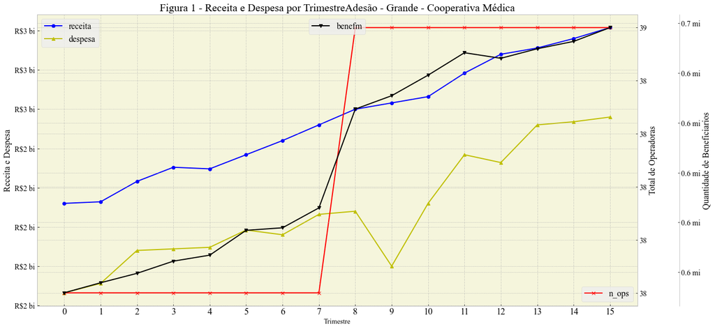

```python
#Visualização geral do dados
df_plot = ans_agrup.copy()

#df_plot.set_index('trimestre', inplace=True)

fig,ax1 = plt.subplots()

df_plot.plot(y=['receita','despesa'],figsize=(20, 10), style=['bo-','y^-'], ax=ax1)
ax1.set_title('Figura 1 - Receita e Despesa por Trimestre' + grupo,fontsize = 20)
ax1.set_xticks(df_plot.index)
ax1.set_xticklabels(df_plot.index)
ax1.set_xlabel('Trimestre', fontsize = 13)
yticks = ax1.get_yticks()
ax1.set_yticklabels(['R${:.0f} bi'.format(x) for x in yticks], fontsize = 14)
ax1.set_ylabel('Receita e Despesa', fontsize=16)
ax1.legend(loc = 'upper left', fontsize = 16)
ax1.set_facecolor("beige")
ax1.grid(linestyle='-.', axis='x')

ax2 = ax1.twinx()

df_plot.plot(y=['n_ops'], figsize=(20,10), style=['rx-'], ax=ax2)
ax2.set_xticks(df_plot.index)
ax2.set_xticklabels(df_plot.index)
ax2.set_xlabel('Trimestre', fontsize = 13)
yticks = ax2.get_yticks()
ax2.set_yticklabels(yticks.astype(int), fontsize = 14)
ax2.set_ylabel('Total de Operadoras', fontsize=16)
ax2.legend(loc = 'lower right', fontsize = 16)

ax3 = ax1.twinx()

ax3.spines.right.set_position(("axes", 1.07))

df_plot.plot(y=['benefm'], figsize=(20,10), style=['kv-'], ax=ax3)
ax3.set_xticks(df_plot.index)
ax3.set_xticklabels(df_plot.index)
ax3.set_xlabel('Trimestre', fontsize = 13)
yticks = ax3.get_yticks()
ax3.set_yticklabels(['{:.1f} mi'.format(x/1e6) for x in yticks], fontsize = 14)
ax3.set_ylabel('Quantidade de Beneficiarios', fontsize=16)
ax3.legend(loc = 'upper center', fontsize = 16)

plt.show()

del df_plot
```

### Especificação do modelo

Busca do ordem do Lag a ser utilizado do modelo

Com *select_order()* podemos escolher a ordem do lag de acordo com vários critérios de informação (AIC, BIC, HQIC e FPE).

Para encontrar o melhor número de diferenças defasadas de acordo com um critério de informação específico, podemos usar o método summary() do objeto LagOrderResults retornado.

Procuramos então o asterisco (*) (=valor mínimo) na coluna de interesse da SimpleTable.

```python
ans_agrup.set_index('trimestre', inplace=True)
ans_agrup = ans_agrup[['receita','despesa','benefm']]


lag_order = select_order(data=ans_agrup, maxlags=10, deterministic="ci", seasons=4)
lag_order.summary()
```

VECM Order Selection (* highlights the minimums)

|  | AIC | BIC | FPE | HQIC |
| --- | --- | --- | --- | --- |
| 0 | -149.3 | -151.2 | -7.703e-68* | -154.4 |
| 1 | -150.0 | -152.6 | -2.447e-70 | -156.9 |
| 2 | -140.5 | -143.8 | -4.438e-68 | -149.3 |
| 3 | -141.4 | -145.4 | -3.359e-70 | -152.1 |
| 4 | -156.4 | -161.1 | -2.098e-78 | -169.0 |
| 5 | -160.8* | -166.2* | -5.555e-82 | -175.3* |
| 6 | -156.1 | -162.2 | -1.465e-81 | -172.4 |
| 7 | -150.8 | -157.6 | -6.906e-81 | -169.1 |
| 8 | -145.6 | -153.1 | -3.212e-80 | -165.7 |
| 9 | -143.8 | -152.0 | -4.598e-81 | -165.9 |
| 10 | -138.8 | -147.7 | -1.914e-80 | -162.7 |

```python
print(lag_order)
```

```
<statsmodels.tsa.vector_ar.var_model.LagOrderResults object. Selected orders are: AIC -> 5, BIC -> 5, FPE -> 0, HQIC ->  5>
```

```python
lag_order.aic, lag_order.bic, lag_order.fpe, lag_order.hqic
```

```
(5, 5, 0, 5)
```

### Rank Cointegração

A função "select_coint_rank" nos ajuda a escolher o rank de cointegração. O atributo de classificação do objeto CointRankResults resultante nos fornece as informações desejadas.

```python
rank_test = select_coint_rank(ans_agrup, 0, 5, method="trace", signif=0.05)
rank_test.rank
```

```
3
```

Podemos usar o método summary() do CointRankResults para ver mais detalhes.

Cada linha da SimpleTable resultante mostra um teste com a hipótese nula "O posto de cointegração é r_0" e "O posto de cointegração é maior que r_0 e r_1".

A última linha contém as informações sobre o posto de cointegração a ser escolhido.

Se sua estatística de teste for menor que seu valor crítico, use r_0 como classificação de cointegração. Caso contrário, use r_1.

```python
rank_test.summary()
```

Johansen cointegration test using trace test statistic with 5% significance level

| r_0 | r_1 | test statistic | critical value |
| --- | --- | --- | --- |
| 0 | 3 | 317.2 | 29.80 |
| 1 | 3 | 153.4 | 15.49 |
| 2 | 3 | 18.26 | 3.841 |

```python
print(rank_test)
```

```
Johansen cointegration test using trace test statistic with 5% significance level
=====================================
r_0 r_1 test statistic critical value
-------------------------------------
  0   3          317.2          29.80
  1   3          153.4          15.49
  2   3          18.26          3.841
-------------------------------------
```

### Estimativa de parâmetro

Para ajustar um VECM aos dados, primeiro construímos um objeto VECM onde definimos

1. os termos determinísticos
2. a ordem de atraso (lag)
3. o posto de cointegração.

Discutimos todos os três tópicos acima. Temos sugestões diferentes para a ordem de defasagem dependendo do critério de informação que usamos.

Seguiremos o critério de informação Akaike (AIC) usando lag_order.aic.

Assim que tivermos a instância VECM, podemos chamar seu método fit() que retorna um objeto VECMResults.

Este objeto oferece um método summary() listando todos os parâmetros do modelo com os erros padrão correspondentes, etc.

```python
model = VECM(ans_agrup, deterministic="ci", seasons=4,
             k_ar_diff=lag_order.aic,  # = 5
             coint_rank=rank_test.rank)  # = 3
```

```python
vecm_res = model.fit()
```

```python
vecm_res.summary()
```

Det. terms outside the coint. relation & lagged endog. parameters for equation receita

|  | coef | std err | z | P>\|z\| | [0.025 | 0.975] |
| --- | --- | --- | --- | --- | --- | --- |
| season1 | 0.1851 | nan | nan | nan | nan | nan |
| season2 | 0.2118 | nan | nan | nan | nan | nan |
| season3 | 0.0088 | 1.85e+06 | 4.74e-09 | 1.000 | -3.63e+06 | 3.63e+06 |
| L1.receita | 0.0635 | nan | nan | nan | nan | nan |
| L1.despesa | -0.2204 | 5.54e+06 | -3.98e-08 | 1.000 | -1.09e+07 | 1.09e+07 |
| L1.benefm | -1.618e-06 | 40.043 | -4.04e-08 | 1.000 | -78.483 | 78.483 |
| L2.receita | -0.3274 | 1.88e+07 | -1.74e-08 | 1.000 | -3.69e+07 | 3.69e+07 |
| L2.despesa | 0.0171 | nan | nan | nan | nan | nan |
| L2.benefm | 2.568e-06 | 103.355 | 2.49e-08 | 1.000 | -202.571 | 202.571 |
| L3.receita | -0.1956 | 1.62e+07 | -1.21e-08 | 1.000 | -3.18e+07 | 3.18e+07 |
| L3.despesa | 0.0364 | 6.65e+06 | 5.48e-09 | 1.000 | -1.3e+07 | 1.3e+07 |
| L3.benefm | 3.184e-06 | nan | nan | nan | nan | nan |
| L4.receita | -0.0290 | 1.63e+07 | -1.78e-09 | 1.000 | -3.19e+07 | 3.19e+07 |
| L4.despesa | 0.0064 | nan | nan | nan | nan | nan |
| L4.benefm | -1.994e-06 | nan | nan | nan | nan | nan |
| L5.receita | 0.5290 | nan | nan | nan | nan | nan |
| L5.despesa | -0.1302 | 1.12e+07 | -1.16e-08 | 1.000 | -2.2e+07 | 2.2e+07 |
| L5.benefm | 4.136e-06 | nan | nan | nan | nan | nan |

Det. terms outside the coint. relation & lagged endog. parameters for equation despesa

|  | coef | std err | z | P>\|z\| | [0.025 | 0.975] |
| --- | --- | --- | --- | --- | --- | --- |
| season1 | -0.5927 | nan | nan | nan | nan | nan |
| season2 | -1.0626 | nan | nan | nan | nan | nan |
| season3 | -0.5527 | 6.62e+06 | -8.35e-08 | 1.000 | -1.3e+07 | 1.3e+07 |
| L1.receita | 0.5691 | nan | nan | nan | nan | nan |
| L1.despesa | -0.5743 | 1.98e+07 | -2.9e-08 | 1.000 | -3.88e+07 | 3.88e+07 |
| L1.benefm | 1.436e-05 | 143.073 | 1e-07 | 1.000 | -280.418 | 280.418 |
| L2.receita | -0.4080 | 6.72e+07 | -6.07e-09 | 1.000 | -1.32e+08 | 1.32e+08 |
| L2.despesa | -1.1926 | nan | nan | nan | nan | nan |
| L2.benefm | 1.218e-05 | 369.282 | 3.3e-08 | 1.000 | -723.780 | 723.780 |
| L3.receita | -0.4895 | 5.8e+07 | -8.45e-09 | 1.000 | -1.14e+08 | 1.14e+08 |
| L3.despesa | 0.6915 | 2.37e+07 | 2.91e-08 | 1.000 | -4.65e+07 | 4.65e+07 |
| L3.benefm | -6.157e-06 | nan | nan | nan | nan | nan |
| L4.receita | -2.0476 | 5.81e+07 | -3.52e-08 | 1.000 | -1.14e+08 | 1.14e+08 |
| L4.despesa | -1.4101 | nan | nan | nan | nan | nan |
| L4.benefm | -1.985e-06 | nan | nan | nan | nan | nan |
| L5.receita | -2.0465 | nan | nan | nan | nan | nan |
| L5.despesa | -1.3939 | 4.01e+07 | -3.48e-08 | 1.000 | -7.85e+07 | 7.85e+07 |
| L5.benefm | 3.663e-05 | nan | nan | nan | nan | nan |

Det. terms outside the coint. relation & lagged endog. parameters for equation benefm

|  | coef | std err | z | P>\|z\| | [0.025 | 0.975] |
| --- | --- | --- | --- | --- | --- | --- |
| season1 | 5.53e+04 | nan | nan | nan | nan | nan |
| season2 | 4.386e+04 | nan | nan | nan | nan | nan |
| season3 | -5031.1319 | 3.18e+11 | -1.58e-08 | 1.000 | -6.24e+11 | 6.24e+11 |
| L1.receita | 1.638e+04 | nan | nan | nan | nan | nan |
| L1.despesa | -4.096e+04 | 9.52e+11 | -4.3e-08 | 1.000 | -1.87e+12 | 1.87e+12 |
| L1.benefm | -0.6250 | 6.88e+06 | -9.09e-08 | 1.000 | -1.35e+07 | 1.35e+07 |
| L2.receita | -3.277e+04 | 3.23e+12 | -1.01e-08 | 1.000 | -6.34e+12 | 6.34e+12 |
| L2.despesa | 8192.0000 | nan | nan | nan | nan | nan |
| L2.benefm | 0.7500 | 1.78e+07 | 4.22e-08 | 1.000 | -3.48e+07 | 3.48e+07 |
| L3.receita | 1.638e+04 | 2.79e+12 | 5.88e-09 | 1.000 | -5.46e+12 | 5.46e+12 |
| L3.despesa | 6144.0000 | 1.14e+12 | 5.38e-09 | 1.000 | -2.24e+12 | 2.24e+12 |
| L3.benefm | 0.0625 | nan | nan | nan | nan | nan |
| L4.receita | 4.915e+04 | 2.8e+12 | 1.76e-08 | 1.000 | -5.48e+12 | 5.48e+12 |
| L4.despesa | 2.867e+04 | nan | nan | nan | nan | nan |
| L4.benefm | -0.7188 | nan | nan | nan | nan | nan |
| L5.receita | 0 | nan | nan | nan | nan | nan |
| L5.despesa | 3.277e+04 | 1.93e+12 | 1.7e-08 | 1.000 | -3.78e+12 | 3.78e+12 |
| L5.benefm | -0.2500 | nan | nan | nan | nan | nan |

Loading coefficients (alpha) for equation receita

|  | coef | std err | z | P>\|z\| | [0.025 | 0.975] |
| --- | --- | --- | --- | --- | --- | --- |
| ec1 | -0.5664 | nan | nan | nan | nan | nan |
| ec2 | 0.3399 | nan | nan | nan | nan | nan |
| ec3 | 1.468e-06 | 1.467 | 1e-06 | 1.000 | -2.874 | 2.874 |

Loading coefficients (alpha) for equation despesa

|  | coef | std err | z | P>\|z\| | [0.025 | 0.975] |
| --- | --- | --- | --- | --- | --- | --- |
| ec1 | -1.1205 | nan | nan | nan | nan | nan |
| ec2 | 0.3716 | nan | nan | nan | nan | nan |
| ec3 | 7.547e-06 | 5.240 | 1.44e-06 | 1.000 | -10.270 | 10.270 |

Loading coefficients (alpha) for equation benefm

|  | coef | std err | z | P>\|z\| | [0.025 | 0.975] |
| --- | --- | --- | --- | --- | --- | --- |
| ec1 | 7.887e+04 | nan | nan | nan | nan | nan |
| ec2 | -1.442e+04 | nan | nan | nan | nan | nan |
| ec3 | -0.6973 | 2.52e+05 | -2.77e-06 | 1.000 | -4.94e+05 | 4.94e+05 |

Cointegration relations for loading-coefficients-column 1

|  | coef | std err | z | P>\|z\| | [0.025 | 0.975] |
| --- | --- | --- | --- | --- | --- | --- |
| beta.1 | 1.0000 | 0 | 0 | 0.000 | 1.000 | 1.000 |
| beta.2 | 1.598e-14 | 0 | 0 | 0.000 | 1.6e-14 | 1.6e-14 |
| beta.3 | -1.979e-19 | 0 | 0 | 0.000 | -1.98e-19 | -1.98e-19 |
| const | 5.6056 | 2.955 | 1.897 | 0.058 | -0.186 | 11.398 |

Cointegration relations for loading-coefficients-column 2

|  | coef | std err | z | P>\|z\| | [0.025 | 0.975] |
| --- | --- | --- | --- | --- | --- | --- |
| beta.1 | -8.893e-15 | 0 | 0 | 0.000 | -8.89e-15 | -8.89e-15 |
| beta.2 | 1.0000 | 0 | 0 | 0.000 | 1.000 | 1.000 |
| beta.3 | 4.701e-20 | 0 | 0 | 0.000 | 4.7e-20 | 4.7e-20 |
| const | 9.0169 | 3.853 | 2.341 | 0.019 | 1.466 | 16.568 |

Cointegration relations for loading-coefficients-column 3

|  | coef | std err | z | P>\|z\| | [0.025 | 0.975] |
| --- | --- | --- | --- | --- | --- | --- |
| beta.1 | 5.755e-10 | 0 | 0 | 0.000 | 5.75e-10 | 5.75e-10 |
| beta.2 | -9.416e-10 | 0 | 0 | 0.000 | -9.42e-10 | -9.42e-10 |
| beta.3 | 1.0000 | 0 | 0 | 0.000 | 1.000 | 1.000 |
| const | 9.018e+04 | 2.53e+05 | 0.356 | 0.722 | -4.07e+05 | 5.87e+05 |

```python
vecm_res.alpha
```

```
array([[-5.66411518e-01,  3.39857444e-01,  1.46776271e-06],
       [-1.12045188e+00,  3.71613287e-01,  7.54656565e-06],
       [ 7.88704098e+04, -1.44191431e+04, -6.97272323e-01]])
```

```python
vecm_res.stderr_alpha
```

```
array([[           nan,            nan, 1.46656544e+00],
       [           nan,            nan, 5.23998312e+00],
       [           nan,            nan, 2.51949713e+05]])
```

### Previsões

Para obter uma previsão para os próximos períodos é so chamar o método predict() passando como argumento steps (quantidade de pontos a ser previstos pelo modelo).

Para obter intervalos de confiança, também passamos o nível de confiança desejado para o argumento alpha.

```python
vecm_res.predict(steps=12)
```

```
array([[ 3.47405820e+00,  2.34896031e+00,  7.12411654e+05],
       [ 3.52864723e+00,  2.32612511e+00,  7.17578876e+05],
       [ 3.37287376e+00,  3.03577879e+00,  7.22367313e+05],
       [ 3.44415018e+00,  2.86315657e+00,  6.38713820e+05],
       [ 3.70736943e+00,  7.25111656e-01,  7.41376645e+05],
       [ 3.59254783e+00,  4.19224469e+00,  7.12519430e+05],
       [ 3.13960210e+00,  5.85253193e+00,  5.86339526e+05],
       [ 4.16949579e+00, -2.69691635e+00,  6.58710937e+05],
       [ 3.19421042e+00, -5.52629145e-01,  1.01448799e+06],
       [ 2.08314819e+00,  1.82920530e+01,  4.74558765e+05],
       [ 5.02552620e+00, -6.62934135e+00,  3.34320327e+05],
       [ 5.73882257e+00, -2.49590532e+01,  1.62017998e+06]])
```

```python
#vecm_res.predict(steps=12, alpha=0.05)
for text, vaĺues in zip(("forecast", "lower", "upper"), vecm_res.predict(steps=12, alpha=0.05)):
    print(text+":", vaĺues, sep="\n")
```

```
forecast:
[[ 3.47405820e+00  2.34896031e+00  7.12411654e+05]
 [ 3.52864723e+00  2.32612511e+00  7.17578876e+05]
 [ 3.37287376e+00  3.03577879e+00  7.22367313e+05]
 [ 3.44415018e+00  2.86315657e+00  6.38713820e+05]
 [ 3.70736943e+00  7.25111656e-01  7.41376645e+05]
 [ 3.59254783e+00  4.19224469e+00  7.12519430e+05]
 [ 3.13960210e+00  5.85253193e+00  5.86339526e+05]
 [ 4.16949579e+00 -2.69691635e+00  6.58710937e+05]
 [ 3.19421042e+00 -5.52629145e-01  1.01448799e+06]
 [ 2.08314819e+00  1.82920530e+01  4.74558765e+05]
 [ 5.02552620e+00 -6.62934135e+00  3.34320327e+05]
 [ 5.73882257e+00 -2.49590532e+01  1.62017998e+06]]
lower:
[[ 3.21302292e+00  1.41629109e+00  6.67566902e+05]
 [ 3.18734551e+00  8.13459303e-01  6.58257940e+05]
 [ 2.79830680e+00  1.14181558e+00  6.53642716e+05]
 [ 2.73604097e+00  5.96034544e-01  5.42753867e+05]
 [ 2.97336839e+00 -2.39090033e+00  6.10674499e+05]
 [ 2.47159997e+00 -1.53581513e+00  5.55575761e+05]
 [ 1.89580860e+00 -1.77307326e+00  3.07834426e+05]
 [ 2.60923086e+00 -1.71494722e+01  2.50815728e+05]
 [ 6.61145742e-01 -2.06125523e+01  4.71515826e+05]
 [-1.42011483e+00 -1.14616648e+01 -4.78133951e+05]
 [-8.63770248e-01 -5.90647183e+01 -9.17876035e+05]
 [-1.89152567e+00 -9.29682513e+01 -4.77116809e+05]]
upper:
[[3.73509348e+00 3.28162953e+00 7.57256406e+05]
 [3.86994894e+00 3.83879092e+00 7.76899812e+05]
 [3.94744071e+00 4.92974199e+00 7.91091911e+05]
 [4.15225938e+00 5.13027860e+00 7.34673773e+05]
 [4.44137046e+00 3.84112364e+00 8.72078790e+05]
 [4.71349570e+00 9.92030450e+00 8.69463098e+05]
 [4.38339559e+00 1.34781371e+01 8.64844626e+05]
 [5.72976072e+00 1.17556395e+01 1.06660615e+06]
 [5.72727509e+00 1.95072940e+01 1.55746015e+06]
 [5.58641122e+00 4.80457709e+01 1.42725148e+06]
 [1.09148227e+01 4.58060356e+01 1.58651669e+06]
 [1.33691708e+01 4.30501450e+01 3.71747677e+06]]
```

[figure not shown]

```python
vecm_res.plot_forecast(steps=12, plot_conf_int=False)
```

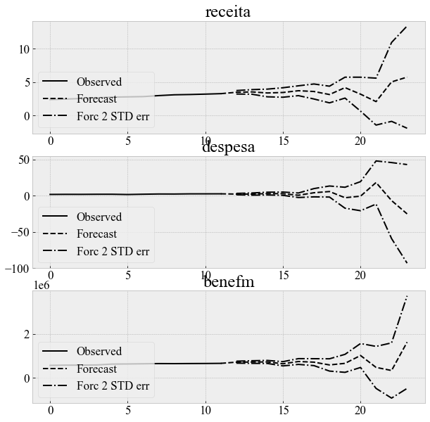

```python
vecm_res.plot_forecast(steps=12, n_last_obs=12)
```

### Representações alternativas

#### Representação de modelo VAR

Cada VECM tem um modelo VAR correspondente.

Para obter suas matrizes de parâmetros (onde é o número de lags nos níveis) podemos usar o método var_rep().

```python
print(vecm_res.var_rep[0])  # A_1
vecm_res.var_rep
```

```
[[ 4.97136749e-01  1.19424470e-01 -1.50196268e-07]
 [-5.51349019e-01  7.97305676e-01  2.19088805e-05]
 [ 9.52544098e+04 -5.53791431e+04 -3.22272323e-01]]
```

```
array([[[ 4.97136749e-01,  1.19424470e-01, -1.50196268e-07],
        [-5.51349019e-01,  7.97305676e-01,  2.19088805e-05],
        [ 9.52544098e+04, -5.53791431e+04, -3.22272323e-01]],

       [[-3.90975303e-01,  2.37527544e-01,  4.18641650e-06],
        [-9.77096776e-01, -6.18309674e-01, -2.18343492e-06],
        [-4.91520000e+04,  4.91520000e+04,  1.37500000e+00]],

       [[ 1.31833003e-01,  1.93453599e-02,  6.15359302e-07],
        [-8.15426025e-02,  1.88413898e+00, -1.83356882e-05],
        [ 4.91520000e+04, -2.04800000e+03, -6.87500000e-01]],

       [[ 1.66625443e-01, -3.00665169e-02, -5.17773947e-06],
        [-1.55809086e+00, -2.10162024e+00,  4.17160623e-06],
        [ 3.27680000e+04,  2.25280000e+04, -7.81250000e-01]],

       [[ 5.57997628e-01, -1.36583393e-01,  6.13024034e-06],
        [ 1.12300447e-03,  1.62191461e-02,  3.86185295e-05],
        [-4.91520000e+04,  4.09600000e+03,  4.68750000e-01]],

       [[-5.29029038e-01,  1.30209980e-01, -4.13631769e-06],
        [ 2.04650437e+00,  1.39387941e+00, -3.66333275e-05],
        [-0.00000000e+00, -3.27680000e+04,  2.50000000e-01]]])
```

```python
vecm_res.ma_rep(maxn=2)
```

```
array([[[ 1.00000000e+00,  0.00000000e+00,  0.00000000e+00],
        [ 0.00000000e+00,  1.00000000e+00,  0.00000000e+00],
        [ 0.00000000e+00,  0.00000000e+00,  1.00000000e+00]],

       [[ 4.97136749e-01,  1.19424470e-01, -1.50196268e-07],
        [-5.51349019e-01,  7.97305676e-01,  2.19088805e-05],
        [ 9.52544098e+04, -5.53791431e+04, -3.22272323e-01]],

       [[-2.23981777e-01,  4.00433385e-01,  6.77660895e-06],
        [ 3.96131144e-01, -1.26175293e+00,  8.30682463e-06],
        [-1.96215610e+03,  3.42207673e+04,  2.51257565e-01]]])
```

### Análise estrutural

#### Causalidade de Granger

O método test_granger_causality() permite testar a causalidade de Granger.

O objeto CausalityTestResults retornado oferece um resumo do teste por meio de seu método summary().

```python
# Teste de Causalidade de Granger
granger_results = vecm_res.test_granger_causality(caused="receita", signif=0.05)
granger_results.summary()
```

Granger causality F-test. H_0: ['despesa', 'benefm'] do not Granger-cause receita. Conclusion: reject H_0 at 5% significance level.

| Test statistic | Critical value | p-value | df |
| --- | --- | --- | --- |
| 3.133e+06 | nan | NAN | (12, -48) |

```python
print(granger_results)
```

```
<statsmodels.tsa.vector_ar.hypothesis_test_results.CausalityTestResults object. H_0: ['despesa', 'benefm'] do not Granger-cause receita: reject at 5% significance level. Test statistic: 3132999.266, critical value: nan>, p-value: nan>
```

```python
granger_results.signif, granger_results.pvalue
```

```
(0.05, nan)
```

### Causalidade instantânea

Os testes de causalidade instantânea são executados de maneira semelhante usando o método test_inst_causality().

Novamente, um objeto CausalityTestResults é retornado.

```python
inst_caus_rec_desp = vecm_res.test_inst_causality(causing="receita")
inst_caus_desp_rec = vecm_res.test_inst_causality(causing="despesa")
inst_caus_rec_desp.summary()
```

Instantaneous causality Wald-test. H_0: receita does not instantaneously cause [despesa, benefm]. Conclusion: fail to reject H_0 at 5% significance level.

| Test statistic | Critical value | p-value | df |
| --- | --- | --- | --- |
| 2.756 | 5.991 | 0.252 | 2 |

Também podemos comparar objetos HypothesisTestResults (HypothesisTestResults é a classe base de CausalityTestResults).

A causalidade de Granger não é uma relação simétrica, portanto, a troca de variáveis leva a instâncias de CausalityTestResults que não são iguais.

```python
inst_caus_rec_desp == inst_caus_desp_rec
```

```
False
```

```python
granger_results == vecm_res.test_granger_causality(caused="receita", signif=0.05)
```

```
False
```

### Análise de Impulso-Resposta

Para analisar como um impulso em uma variável afeta o sistema, podemos usar o método irf() e chamar o método plot do objeto retornado.

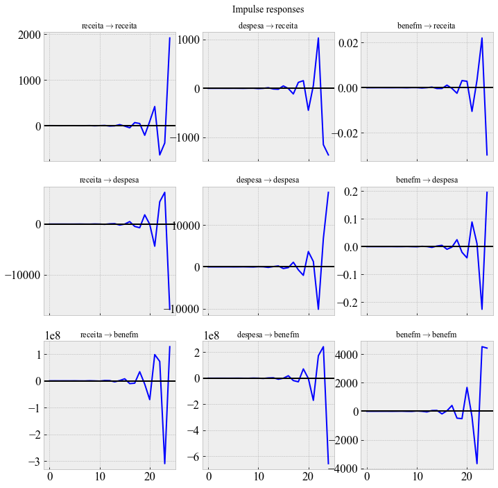

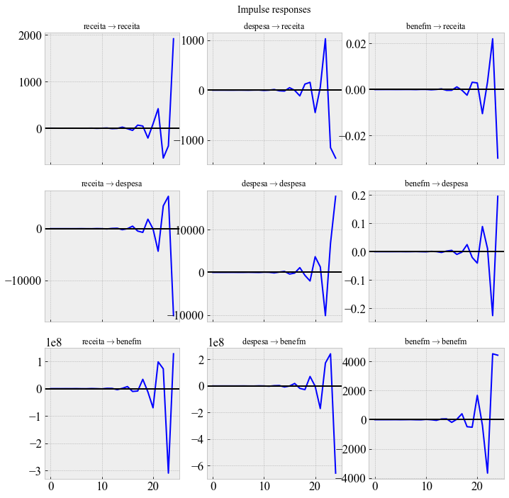

```python
num_periods = 24
ir = vecm_res.irf(periods=num_periods)
ir.plot(plot_stderr=False)
```

### Diagnóstico

O teste de não normalidade e de autocorrelação residual é possível com os métodos test_normality() e test_whiteness() que retornam um objeto NormalityTestResults e um objeto WhitenessTestResults, respectivamente.

Ambas as classes mencionadas são subclasses de HypothesisTestResults - assim como no caso dos testes de causalidade. Portanto, novamente temos as mesmas possibilidades acima para inspecionar esses objetos.

### Teste de não normalidade

```python
norm_test = vecm_res.test_normality()
norm_test.summary()
```

normality (skew and kurtosis) test. H_0: data generated by normally-distributed process. Conclusion: fail to reject H_0 at 5% significance level.

| Test statistic | Critical value | p-value | df |
| --- | --- | --- | --- |
| 5.200 | 12.59 | 0.518 | 6 |

```python
print(norm_test)
```

```
<statsmodels.tsa.vector_ar.hypothesis_test_results.NormalityTestResults object. H_0: data generated by normally-distributed process: fail to reject at 5% significance level. Test statistic: 5.200, critical value: 12.592>, p-value: 0.518>
```

```python
norm_test.test_statistic, norm_test.crit_value, norm_test.pvalue
```

```
(5.200383766975637, 12.591587243743977, 0.5183814056711016)
```

### Verificando a autocorrelação residual

```python
white_test = vecm_res.test_whiteness(nlags=6, adjusted=True)
white_test.summary()
```

Adjusted Portmanteau-test for residual autocorrelation. H_0: residual autocorrelation up to lag 6 is zero. Conclusion: reject H_0 at 5% significance level.

| Test statistic | Critical value | p-value | df |
| --- | --- | --- | --- |
| 47.56 | nan | NAN | 0 |

```python
print(white_test)
```

```
<statsmodels.tsa.vector_ar.hypothesis_test_results.WhitenessTestResults object. H_0: residual autocorrelation up to lag 6 is zero: reject at 5% significance level. Test statistic: 47.565, critical value: nan>, p-value: nan>
```

```python
white_test.test_statistic, white_test.crit_value, white_test.pvalue
```

```
(47.56486225359337, nan, nan)
```